# Economic Recovery Indicators How-To Guide

BC Stats

Last updated: 2021-02-18

## Background

The **British Columbia - Economic Recovery Indicators** report began in September 2020 as a bi-weekly PDF report that provides readers a view of select data relevant for monitoring the impacts of COVID-19 in BC and exploring key economic trends as the COVID-19 situation evolves. It was transitioned to an online shiny application (https://bcstats.shinyapps.io/Economic-Indicators/) as of February 22, 2021, along with monthly PDF reports.

## Indicators Meta-data

In this project’s app folder, the **indicators_list.csv** contains the meta-data needed for each indicator. This is where you would update, *if needed*, which indicators to include in the app, and their corresponding pieces of information.

- *order* determines the charts order. A number entered multiple times indicates a multi-line chart (e.g., “2” is listed 4 times - once for each line in the Non-Residential Building Permits chart).
- *title* is the html-formatted title of each indicator. This is what shows in the tables and most charts, and is what is used to create month-over-month, year-over-year, and year-to-date stats.
- *label* is the non-formatted title of each indicator. It is the title for the multi-line charts.
- *chart_list* is the non-formatted version of label and is used for the drop-down list to choose a chart.
- *line* is the legend entry for multi-line charts. All other charts are “NA”.
- *filter_var* is used to determine which box the indicator belongs to (i.e., “OVERALL ECONOMY”, “BUSINESSES”, or “BRITISH COLUMBIANS”).
- *source* is the source for each indicator. This is needed for charts.
- *vector* is the data vector (e.g., Statistics Canada Cansim data table, Statbase vector, Haver vector, US Census Bureau data table).
- *dataset* is used to determine which data is pulled in the app dynamically (i.e., “cansim_auto”) or updated in R (i.e., “manual”).

## Updating the Data

There are two types of data in the app:

- publicly available CANSIM data pulled on the fly from Statistics Canada
- all other data is updated and the app re-published

### Step 1. Pulling TRIP and Beyond 2020 IVT data

There are two sets of data that need to be updated outside of R, within their own systems: Exports data within TRIP and Indigenous Employment within Beyond 2020.

#### Key Exports by Destination and Commodity

1. Open the TRIP data application.
2. Select the **Pandemic Indicators Report** on the **Canadian Exports tab**.
3. Click the Run Report button.
4. Copy and paste the tab into **TRIPexportdata.xlsx** (one folder above this R project). (The dates and general format should match exactly.)
5. Save and close the Excel file.

#### Indigenous Employment

1. In the correct month and year folder of **Aboriginal LFS**, open **4ctl_abo_cow_3MMA.ivt** with Beyond 2020.
2. Make sure the settings are for Cow: Total employment, Sex: Both sexes, Age: 15 years and over, and, Aboriginal: Aboriginal (not total).
3. Copy and paste the British Columbia row into Beyond2020data.csv. You will have to paste the data transposed into the “Indigenous” column. Make sure the months match up.
4. Save and close the csv file.

#### Remaining data

The rest of the “manual” data is pulled in through R connections in Step 2 (next):

- International Merchandise Exports (from BC Stats’ website)
- US Housing Starts (from Statbase)
- Housing Starts (from Haver)
- Hotel Occupancy Rate (from Statbase)

### Step 2. Creating updated data file in R

1. Double-click on **“economic_recovery_indicators.Rproj”** to open this project in RStudio.
2. In the Files pane (usually, bottom-right), click on the app folder, then the prep_scripts folder, then the **load_data.R** script.
3. Select all (Ctrl + A) and then run all (Ctrl + Enter). This will pull in all the required data, format it as needed, bind it together, and output two .rds files to the app’s data folder.
4. Check the app’s data folder. The two files (exports_data.rds and non_cansim_data.rds) should have a new modified date. If you want, you can view the files by going to the Environment pane (usually, top-right) and clicking on the file name. The data will come up in the (usually, top-left) pane. (Scroll up and down to see more rows. Click on “Filter” (top left) and then within one or more columns to select specific rows.)

*Note*: Three values have been pre-set for this project. If any change, the **app/prep_scripts/private_setup.R** script must be changed accordingly. Specifically, this file sets the:  
* project location (i.e., the project number and name which will likely change every fiscal year)  
* drive location (i.e., the J drive “PROJECTS” folder location, which will likely NOT change)  
* statbase connection (which includes the user id and password, which is why this file should NEVER be pushed to github or published along with the app)

## Updating the App[^1]

Once the data is updated, the app itself needs to be re-published.

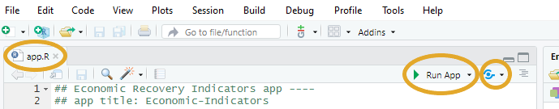

[figure not shown]

## Adding or Removing Indicators

If a new indicator is needed, add it with its meta-data to “indicators_list.csv” (found in the app folder).

- If it’s data from Statistics Canada that can be pulled “on-the-fly”, you just need to make sure the “dataset” column is set to “cansim_auto” and that the correct vector is referenced in the “vector” column. Re-publish the app.
- If it’s data that needs to be added and updated manually (through web scraping, Statbase, Haver, Beyond 2020 ivt, csv or Excel), add the necessary R code to “load_data.R” in the app folder’s prep_scripts folder. Re-run “load_data.R” if needed, then re-publish the app.

If an indicator needs to be removed, just delete its row in “indicators_list.csv” (found in the app folder).

[^1]: If you have never published an app before, you likely need to connect your R to the BC Stats shiny account. First, login to your shiny account (https://www.shinyapps.io/ login or Dashboard option at upper right). Click on Account (on left navigation sidebar) and then choose Tokens. Click the Show button. Click “Show secret”, then “Copy to clipboard”. OK. Back in RStudio, you’ll have to install R’s package “rsconnect” if you haven’t already. Then, click on the Tools menu and choose Global Options. Then, choose Publishing (on left). Click on the Connect button and choose the ShinyApps.io option. Paste into the box your shown secret token from the clipboard and click the Connect Account button.